# ⭐⭐⭐ Parametrise your report

📋 Instructions

Author

Affiliation

Hélène Langet

Swiss TPH Research-IT

Published

March 6, 2026

This exercise builds on the previous exercises where you learnt to create a simple MS Word report ⭐ and to add dynamic elements to your report ⭐⭐. Mastering these two exercises is essential for successfully completing the current exercise.

## 1 Objectives 🎯

- If you have generated the MS Word report with dynamic elements as instructed in Exercise 4, continue working on the same Quarto notebook you already modified. Otherwise, download the files `df1.RData`, `df2.RData`, `exercise5.qmd`, `swisstph_template.docx`, and `my_biblio.bib` using the links provided on the right-hand side of this page. For simplicity, please put these two files under the same folder and open the Quarto notebook in RStudio.
- Complete each of the following tasks and render the document after each task or set of tasks to track your progress.

## 2 Use Quarto in a terminal

- Render your MS Word report using the RStudio Terminal;

```
quarto render exercise5.qmd
```

- Change the output filename when rendering the report;

```
quarto render exercise5.qmd -o exercise5_report1.docx
```

**Tip**

- You can access the RStudio terminal in the `Terminal` tab immediately to the right of the `Console` tab:

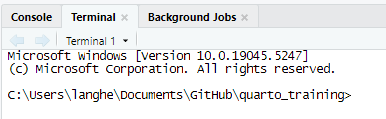

- If the terminal tab is not visible, go to **Tools** > **Terminal** > **Move Focus to Terminal**

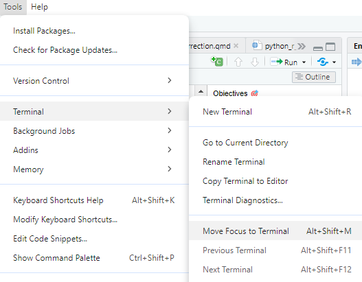

## 3 Parametrise your report

- Adjust the report to focus on data for the year 2022 only ;
- You were unfortunately provided with a previous erroneous version of the dataset. Update the report to use the dataset stored in `df2.RData` instead of the one stored in `df1.RData` ;
- Render 3 reports (1 report with df2.RData for the full outbreak period, 1 report with df1.RData for year 2021 only, 1 report with df2.RData for year 2021 only) adapting the following command which needs to be run in a terminal (ensure your working directory is the one where your Quarto document is stored and all file paths are correct).
- Create a small R script using `purrr::walk()` or a for loop that calls `quarto::quarto_render()` to generate 5 separate reports automatically.
- How would you ensure that the report doesn’t ‘break’ if a user inputs a year that does not exist in the data? How would you implement a ‘sanity check’ code chunk?

```
quarto render exercise5.qmd -o exercise5_report_df1.docx -P dataset:df1.RData
```

**Tip**

- See [Quarto documentation about parameters](https://quarto.org/docs/computations/parameters.html#knitr)
- See [Quarto documentation about rendering outputs using different parameters](https://quarto.org/docs/computations/parameters.html#rendering)

**ImportantDiscussion question**

Discuss the advantages and disadvantages of using R within Quarto compared to using R scripts.